# Lab - Clustering - Code plus a few comments

IA

2023

```r
#clear workspace
rm(list=ls())


library(caret)
library(RColorBrewer)
library(scales)
library(cluster)
library(rattle)
```

```r
library(rgl)
library(fpc)
library(pvclust)
library(ggplot2)
```

Reading the input file

```r
delta <- read.csv(file="delta.csv", header=T, sep=",", row.names=1, stringsAsFactors = T)
```

Apply centering, scaling and principal components analysis (PCA).

```r
pca_delta <- preProcess(delta,
                     method = c("center", "scale", "pca"))
#pca_delta

delta2 <- predict(pca_delta, newdata = delta)
```

## K-means clustering

### Elbow method

Determine the correct number of clusters via within cluster sum of squares. See: http://www.statmethods.net/advstats/cluster.html)

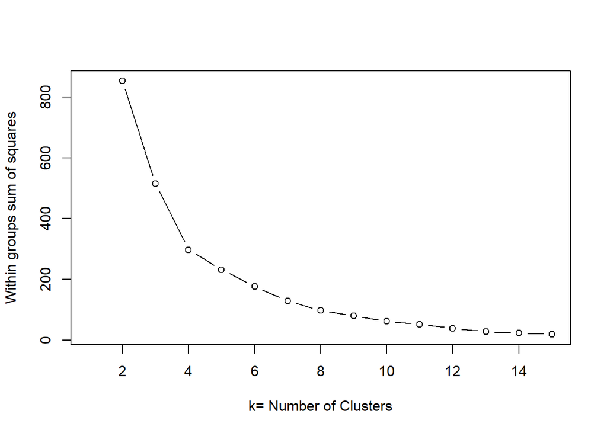

```r
# For each value of k, k-mans is applied and the within clusters sum of squares calculated.
set.seed(1)
wss <- NULL
for (i in 2:15)
    wss[i] <- sum(kmeans(delta2, centers=i, nstart=100, iter.max=1000)$withinss)
plot(1:15, wss, type="b", xlab="k= Number of Clusters", ylab="Within groups sum of squares")
```

```r
wss
```

```
##  [1]        NA 852.49965 514.93498 297.18506 231.46017 176.38891 129.24263
##  [8]  97.37278  79.25121  62.51292  51.63337  38.58613  27.70659  23.22064
## [15]  18.57701
```

k = 4 seems a good compromise.

### Silhouette method

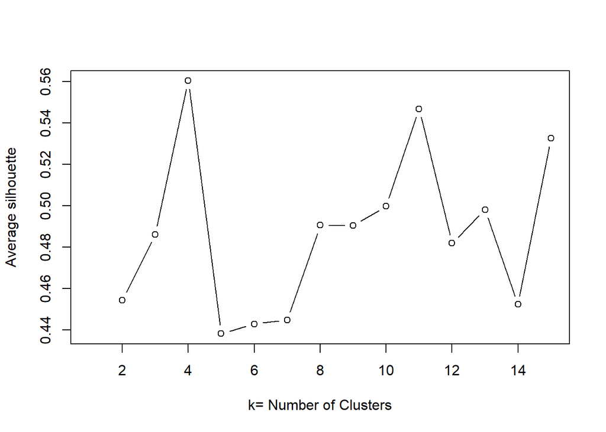

```r
# For each value of k, k-means is applied. The average silhouette is calculated.
set.seed(1)

sil <-NULL
for (i in 2:15)
{
  res <- kmeans(delta2, centers = i, nstart = 25)
  ss <- silhouette(res$cluster, dist(delta2))
  sil[i] <- mean(ss[, 3])
}
plot(1:15, sil, type="b", xlab="k= Number of Clusters", ylab="Average silhouette")
```

k=4 appears to be best for clustering.

## Apply k-means with k=4

```r
set.seed(1)
km <- kmeans(delta2, 4, nstart=25, iter.max=1000)
```

### Viewing results

Checking good separation of clusters (and good cohesion) in 2-D. Are 2 principal components sufficient to distinguish between the resulting clusters?

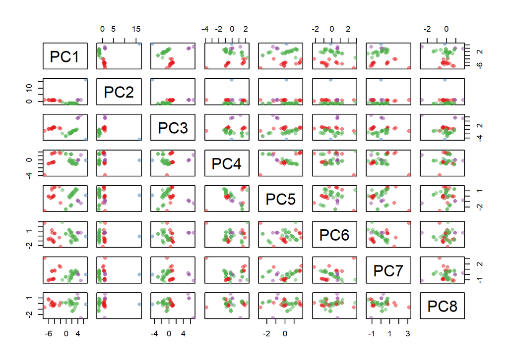

```r
palette(alpha(brewer.pal(9,'Set1'), 0.5))

plot(delta2, col=km$clust, pch=16)
```

### 3D plotting - various principal components

Visualising the first 3 principal components. The cube can be rotated (in RStudio) to check the clusters from different angles. Are the clusters clear?

```r
plot3d(delta2$PC1, delta2$PC2, delta2$PC3, col=km$clust)
```

Visualising principal components 1, 3 and 4.

```r
plot3d(delta2$PC1, delta2$PC3, delta2$PC4, col=km$clust)
```

### Cluster sizes - sort clusters by size

```r
sort(table(km$clust))
```

```
##
##  2  4  1  3
##  1  4 15 24
```

```r
clust <- names(sort(table(km$clust)))
```

The resulting clusters vary in sizes with one cluster having more instances than the other 3 put together. 2 clusters have very few instances.

Note: you may get the same results in a different order - i.e. the cluster label (number) may be different, but the cluster sizes may be the same.

### Getting the instances in each cluster

```r
# First cluster - instances
row.names(delta[km$clust==clust[1],])
```

```
## [1] "Airbus A319 VIP"
```

```r
# Second Cluster - instances
row.names(delta[km$clust==clust[2],])
```

```
## [1] "CRJ 100/200 Pinnacle/SkyWest" "CRJ 100/200 ExpressJet"
## [3] "E120"                         "ERJ-145"
```

```r
# Third Cluster - instances
row.names(delta[km$clust==clust[3],])
```

```
##  [1] "Airbus A330-200"          "Airbus A330-200 (3L2)"
##  [3] "Airbus A330-200 (3L3)"    "Airbus A330-300"
##  [5] "Boeing 747-400 (74S)"     "Boeing 757-200 (75E)"
##  [7] "Boeing 757-200 (75X)"     "Boeing 767-300 (76G)"
##  [9] "Boeing 767-300 (76L)"     "Boeing 767-300 (76T)"
## [11] "Boeing 767-300 (76Z V.1)" "Boeing 767-300 (76Z V.2)"
## [13] "Boeing 767-400 (76D)"     "Boeing 777-200ER"
## [15] "Boeing 777-200LR"
```

```r
# Fourth Cluster - instances
row.names(delta[km$clust==clust[4],])
```

```
##  [1] "Airbus A319"            "Airbus A320"            "Airbus A320 32-R"
##  [4] "Boeing 717"             "Boeing 737-700 (73W)"   "Boeing 737-800 (738)"
##  [7] "Boeing 737-800 (73H)"   "Boeing 737-900ER (739)" "Boeing 757-200 (75A)"
## [10] "Boeing 757-200 (75M)"   "Boeing 757-200 (75N)"   "Boeing 757-200 (757)"
## [13] "Boeing 757-200 (75V)"   "Boeing 757-300"         "Boeing 767-300 (76P)"
## [16] "Boeing 767-300 (76Q)"   "Boeing 767-300 (76U)"   "CRJ 700"
## [19] "CRJ 900"                "E170"                   "E175"
## [22] "MD-88"                  "MD-90"                  "MD-DC9-50"
```

### Compare accommodation by cluster in boxplot

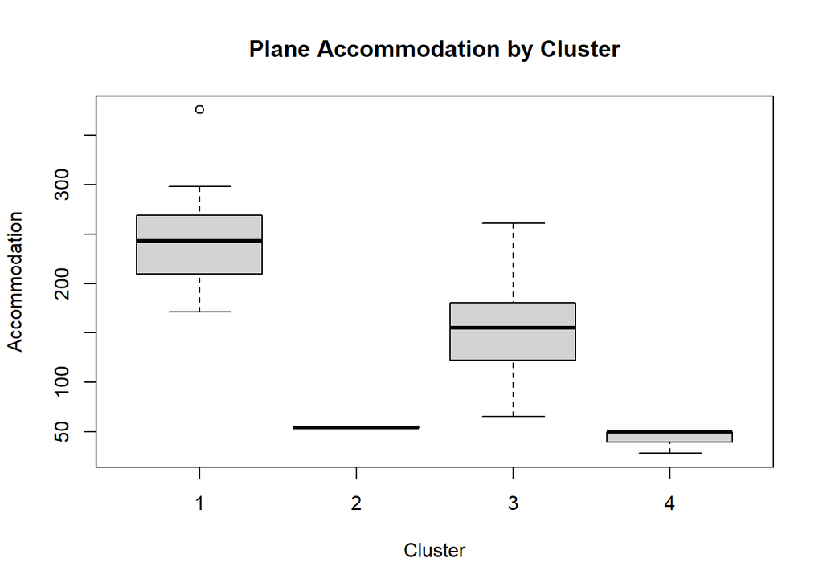

```r
boxplot(delta$Accommodation ~ km$cluster,
        xlab='Cluster', ylab='Accommodation',
        main='Plane Accommodation by Cluster')
```

It can be seen that the clusters correspond to airplane number of seats with a few exceptions.

```r
# Compare presence of seat classes in largest clusters
delta[km$clust==clust[3],30:33]
```

```
##                          First.Class Business Eco.Comfort Economy
## Airbus A330-200                    0        1           1       1
## Airbus A330-200 (3L2)              0        1           1       1
## Airbus A330-200 (3L3)              0        1           1       1
## Airbus A330-300                    0        1           1       1
## Boeing 747-400 (74S)               0        1           1       1
## Boeing 757-200 (75E)               0        1           1       1
## Boeing 757-200 (75X)               0        1           1       1
## Boeing 767-300 (76G)               0        1           1       1
## Boeing 767-300 (76L)               0        1           1       1
## Boeing 767-300 (76T)               0        1           1       1
## Boeing 767-300 (76Z V.1)           0        1           1       1
## Boeing 767-300 (76Z V.2)           0        1           1       1
## Boeing 767-400 (76D)               0        1           1       1
## Boeing 777-200ER                   0        1           1       1
## Boeing 777-200LR                   0        1           1       1
```

```r
delta[km$clust==clust[4],30:33]
```

```
##                        First.Class Business Eco.Comfort Economy
## Airbus A319                      1        0           1       1
## Airbus A320                      1        0           1       1
## Airbus A320 32-R                 1        0           1       1
## Boeing 717                       1        0           1       1
## Boeing 737-700 (73W)             1        0           1       1
## Boeing 737-800 (738)             1        0           1       1
## Boeing 737-800 (73H)             1        0           1       1
## Boeing 737-900ER (739)           1        0           1       1
## Boeing 757-200 (75A)             1        0           1       1
## Boeing 757-200 (75M)             1        0           1       1
## Boeing 757-200 (75N)             1        0           1       1
## Boeing 757-200 (757)             1        0           1       1
## Boeing 757-200 (75V)             1        0           1       1
## Boeing 757-300                   1        0           1       1
## Boeing 767-300 (76P)             1        0           1       1
## Boeing 767-300 (76Q)             1        0           1       1
## Boeing 767-300 (76U)             0        1           1       1
## CRJ 700                          1        0           1       1
## CRJ 900                          1        0           1       1
## E170                             1        0           1       1
## E175                             1        0           1       1
## MD-88                            1        0           1       1
## MD-90                            1        0           1       1
## MD-DC9-50                        1        0           1       1
```

With one exception, one cluster has instances with first class accommodation whereas the other one has instances with business class accommodation instead.

## Exercise 1 - using with other clustering algorithms

### Lloyd

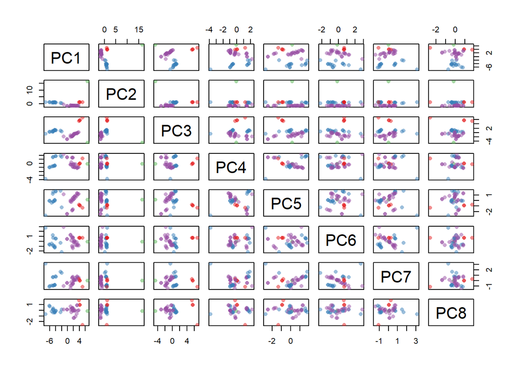

```r
set.seed(1)

km2 <- kmeans(delta2, 4,  algorithm="Lloyd", nstart=25, iter.max=1000)

palette(alpha(brewer.pal(9,'Set1'), 0.5))
plot(delta2, col=km2$clust, pch=16)
```

```r
# 3D plot
plot3d(delta2$PC1, delta2$PC2, delta2$PC3, col=km2$clust)
plot3d(delta2$PC1, delta2$PC3, delta2$PC4, col=km2$clust)

# Cluster sizes
sort(table(km2$clust))
```

```
##
##  3  1  2  4
##  1  4 15 24
```

```r
clust <- names(sort(table(km2$clust)))

# First cluster
row.names(delta[km2$clust==clust[1],])
```

```
## [1] "Airbus A319 VIP"
```

```r
# Second Cluster
row.names(delta[km2$clust==clust[2],])
```

```
## [1] "CRJ 100/200 Pinnacle/SkyWest" "CRJ 100/200 ExpressJet"
## [3] "E120"                         "ERJ-145"
```

```r
# Third Cluster
row.names(delta[km2$clust==clust[3],])
```

```
##  [1] "Airbus A330-200"          "Airbus A330-200 (3L2)"
##  [3] "Airbus A330-200 (3L3)"    "Airbus A330-300"
##  [5] "Boeing 747-400 (74S)"     "Boeing 757-200 (75E)"
##  [7] "Boeing 757-200 (75X)"     "Boeing 767-300 (76G)"
##  [9] "Boeing 767-300 (76L)"     "Boeing 767-300 (76T)"
## [11] "Boeing 767-300 (76Z V.1)" "Boeing 767-300 (76Z V.2)"
## [13] "Boeing 767-400 (76D)"     "Boeing 777-200ER"
## [15] "Boeing 777-200LR"
```

```r
# Fourth Cluster
row.names(delta[km2$clust==clust[4],])
```

```
##  [1] "Airbus A319"            "Airbus A320"            "Airbus A320 32-R"
##  [4] "Boeing 717"             "Boeing 737-700 (73W)"   "Boeing 737-800 (738)"
##  [7] "Boeing 737-800 (73H)"   "Boeing 737-900ER (739)" "Boeing 757-200 (75A)"
## [10] "Boeing 757-200 (75M)"   "Boeing 757-200 (75N)"   "Boeing 757-200 (757)"
## [13] "Boeing 757-200 (75V)"   "Boeing 757-300"         "Boeing 767-300 (76P)"
## [16] "Boeing 767-300 (76Q)"   "Boeing 767-300 (76U)"   "CRJ 700"
## [19] "CRJ 900"                "E170"                   "E175"
## [22] "MD-88"                  "MD-90"                  "MD-DC9-50"
```

### Forgy

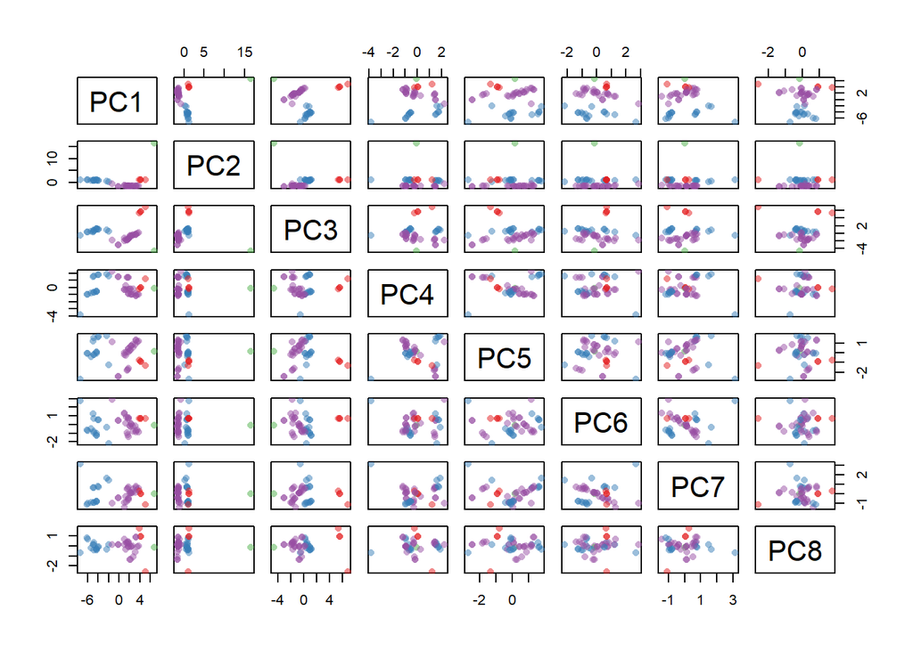

```r
set.seed(1)

km3 <- kmeans(delta2, 4,  algorithm="Forgy", nstart=25, iter.max=1000)

palette(alpha(brewer.pal(9,'Set1'), 0.5))
plot(delta2, col=km3$clust, pch=16)
```

```r
# 3D plot
plot3d(delta2$PC1, delta2$PC2, delta2$PC3, col=km3$clust)
plot3d(delta2$PC1, delta2$PC3, delta2$PC4, col=km3$clust)

# Cluster sizes
sort(table(km3$clust))
```

```
##
##  3  1  2  4
##  1  4 15 24
```

```r
clust <- names(sort(table(km3$clust)))

# First cluster
row.names(delta[km3$clust==clust[1],])
```

```
## [1] "Airbus A319 VIP"
```

```r
# Second Cluster
row.names(delta[km3$clust==clust[2],])
```

```
## [1] "CRJ 100/200 Pinnacle/SkyWest" "CRJ 100/200 ExpressJet"
## [3] "E120"                         "ERJ-145"
```

```r
# Third Cluster
row.names(delta[km3$clust==clust[3],])
```

```
##  [1] "Airbus A330-200"          "Airbus A330-200 (3L2)"
##  [3] "Airbus A330-200 (3L3)"    "Airbus A330-300"
##  [5] "Boeing 747-400 (74S)"     "Boeing 757-200 (75E)"
##  [7] "Boeing 757-200 (75X)"     "Boeing 767-300 (76G)"
##  [9] "Boeing 767-300 (76L)"     "Boeing 767-300 (76T)"
## [11] "Boeing 767-300 (76Z V.1)" "Boeing 767-300 (76Z V.2)"
## [13] "Boeing 767-400 (76D)"     "Boeing 777-200ER"
## [15] "Boeing 777-200LR"
```

```r
# Fourth Cluster
row.names(delta[km3$clust==clust[4],])
```

```
##  [1] "Airbus A319"            "Airbus A320"            "Airbus A320 32-R"
##  [4] "Boeing 717"             "Boeing 737-700 (73W)"   "Boeing 737-800 (738)"
##  [7] "Boeing 737-800 (73H)"   "Boeing 737-900ER (739)" "Boeing 757-200 (75A)"
## [10] "Boeing 757-200 (75M)"   "Boeing 757-200 (75N)"   "Boeing 757-200 (757)"
## [13] "Boeing 757-200 (75V)"   "Boeing 757-300"         "Boeing 767-300 (76P)"
## [16] "Boeing 767-300 (76Q)"   "Boeing 767-300 (76U)"   "CRJ 700"
## [19] "CRJ 900"                "E170"                   "E175"
## [22] "MD-88"                  "MD-90"                  "MD-DC9-50"
```

### MacQueen

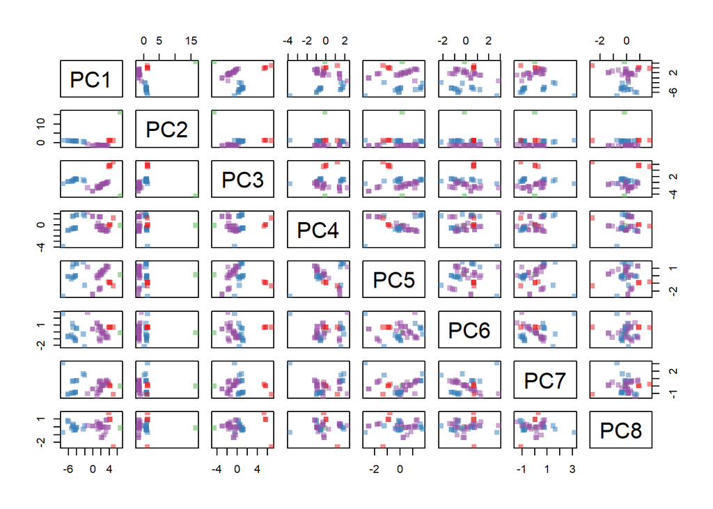

```r
set.seed(1)

km4 <- kmeans(delta2, 4,  algorithm="MacQueen", nstart=25, iter.max=1000)

palette(alpha(brewer.pal(9,'Set1'), 0.5))
plot(delta2, col=km4$clust, pch=15)
```

```r
# 3D plot
plot3d(delta2$PC1, delta2$PC2, delta2$PC3, col=km4$clust)
plot3d(delta2$PC1, delta2$PC3, delta2$PC4, col=km4$clust)

# Cluster sizes
sort(table(km4$clust))
```

```
##
##  3  1  2  4
##  1  4 15 24
```

```r
clust <- names(sort(table(km4$clust)))

# First cluster
row.names(delta[km4$clust==clust[1],])
```

```
## [1] "Airbus A319 VIP"
```

```r
# Second Cluster
row.names(delta[km4$clust==clust[2],])
```

```
## [1] "CRJ 100/200 Pinnacle/SkyWest" "CRJ 100/200 ExpressJet"
## [3] "E120"                         "ERJ-145"
```

```r
# Third Cluster
row.names(delta[km4$clust==clust[3],])
```

```
##  [1] "Airbus A330-200"          "Airbus A330-200 (3L2)"
##  [3] "Airbus A330-200 (3L3)"    "Airbus A330-300"
##  [5] "Boeing 747-400 (74S)"     "Boeing 757-200 (75E)"
##  [7] "Boeing 757-200 (75X)"     "Boeing 767-300 (76G)"
##  [9] "Boeing 767-300 (76L)"     "Boeing 767-300 (76T)"
## [11] "Boeing 767-300 (76Z V.1)" "Boeing 767-300 (76Z V.2)"
## [13] "Boeing 767-400 (76D)"     "Boeing 777-200ER"
## [15] "Boeing 777-200LR"
```

```r
# Fourth Cluster
row.names(delta[km4$clust==clust[4],])
```

```
##  [1] "Airbus A319"            "Airbus A320"            "Airbus A320 32-R"
##  [4] "Boeing 717"             "Boeing 737-700 (73W)"   "Boeing 737-800 (738)"
##  [7] "Boeing 737-800 (73H)"   "Boeing 737-900ER (739)" "Boeing 757-200 (75A)"
## [10] "Boeing 757-200 (75M)"   "Boeing 757-200 (75N)"   "Boeing 757-200 (757)"
## [13] "Boeing 757-200 (75V)"   "Boeing 757-300"         "Boeing 767-300 (76P)"
## [16] "Boeing 767-300 (76Q)"   "Boeing 767-300 (76U)"   "CRJ 700"
## [19] "CRJ 900"                "E170"                   "E175"
## [22] "MD-88"                  "MD-90"                  "MD-DC9-50"
```

All methods appear to give the same results.

## k-medoids

### Apply k-medoids with k=4

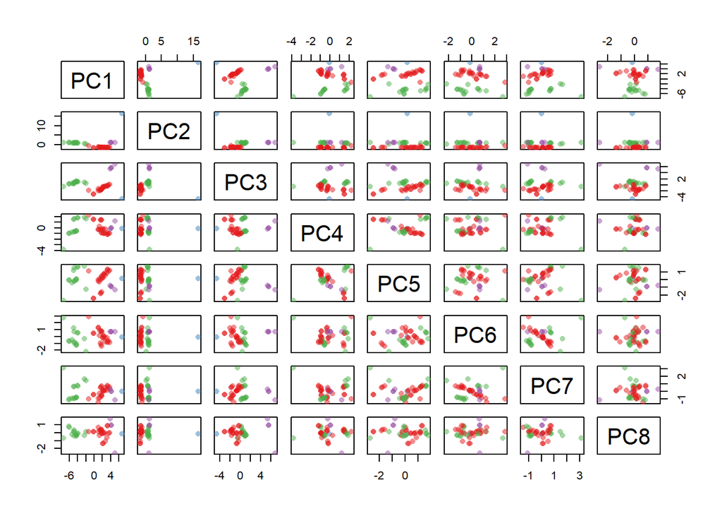

```r
set.seed(1)

kmedoids <- pam(delta2, 4)
#palette(alpha(brewer.pal(9,'Set1'), 0.5))
plot(delta2, col=kmedoids$clust, pch=16)
```

## Adding the cluster number

```r
delta3 <- delta

delta3$cluster <-as.factor(as.character(km$clust))

delta4 <- delta2
delta4$cluster <-as.factor(as.character(km$clust))

ctrl <- trainControl(method="repeatedcv", number=10, repeats=3)

set.seed(123)
mod.rpart1 <- train(cluster~., data=delta3, method="rpart", trControl=ctrl)
print(mod.rpart1)
```

```
## CART
##
## 44 samples
## 33 predictors
##  4 classes: '1', '2', '3', '4'
##
## No pre-processing
## Resampling: Cross-Validated (10 fold, repeated 3 times)
## Summary of sample sizes: 39, 39, 39, 40, 40, 41, ...
## Resampling results across tuning parameters:
##
##   cp     Accuracy   Kappa
##   0.000  0.8938889  0.8231217
##   0.375  0.8938889  0.8231217
##   0.750  0.6866667  0.2897884
##
## Accuracy was used to select the optimal model using the largest value.
## The final value used for the model was cp = 0.375.
```

[figure not shown]

```r
plot(mod.rpart1$finalModel)
```

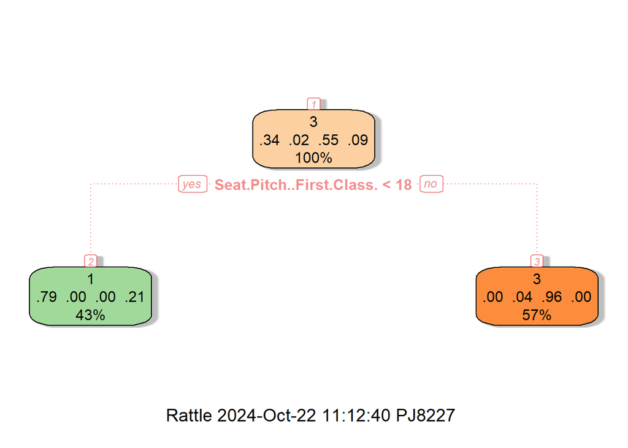

```r
fancyRpartPlot(mod.rpart1$finalModel)
```

```r
set.seed(123)
mod.rpart2 <- train(cluster~., data=delta4, method="rpart", trControl=ctrl)
print(mod.rpart2)
```

```
## CART
##
## 44 samples
##  8 predictor
##  4 classes: '1', '2', '3', '4'
##
## No pre-processing
## Resampling: Cross-Validated (10 fold, repeated 3 times)
## Summary of sample sizes: 39, 39, 39, 40, 40, 41, ...
## Resampling results across tuning parameters:
##
##   cp    Accuracy   Kappa
##   0.00  0.8938889  0.8246032
##   0.10  0.8938889  0.8246032
##   0.75  0.6866667  0.2912698
##
## Accuracy was used to select the optimal model using the largest value.
## The final value used for the model was cp = 0.1.
```

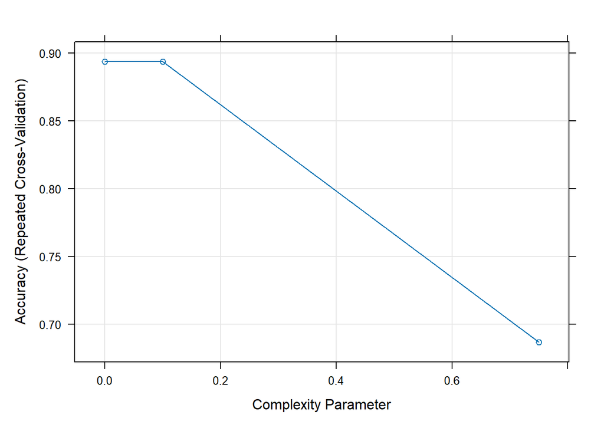

```r
plot(mod.rpart2)
```

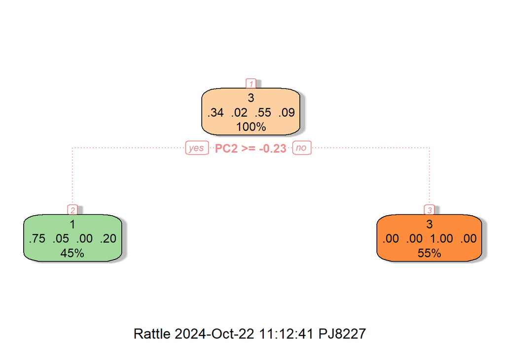

```r
fancyRpartPlot(mod.rpart2$finalModel)
```

## Exercise 2

```r
set.seed(123)
mod.rpart3 <- train(cluster~., data=delta3, method="C5.0Tree", trControl=ctrl)
print(mod.rpart3)
```

```
## Single C5.0 Tree
##
## 44 samples
## 33 predictors
##  4 classes: '1', '2', '3', '4'
##
## No pre-processing
## Resampling: Cross-Validated (10 fold, repeated 3 times)
## Summary of sample sizes: 39, 39, 39, 40, 40, 41, ...
## Resampling results:
##
##   Accuracy   Kappa
##   0.9605556  0.9348369
```

```r
summary(mod.rpart3$finalModel)
```

```
##
## Call:
## C50:::C5.0.default(x = x, y = y, weights = wts)
##
##
## C5.0 [Release 2.07 GPL Edition]      Tue Oct 22 11:12:42 2024
## -------------------------------
##
## Class specified by attribute `outcome'
##
## Read 44 cases (34 attributes) from undefined.data
##
## Decision tree:
##
## Seat.Width..First.Class. > 0: 3 (25/1)
## Seat.Width..First.Class. <= 0:
## :...Video <= 0: 4 (4)
##     Video > 0: 1 (15)
##
##
## Evaluation on training data (44 cases):
##
##      Decision Tree
##    ----------------
##    Size      Errors
##
##       3    1( 2.3%)   <<
##
##
##     (a)   (b)   (c)   (d)    <-classified as
##    ----  ----  ----  ----
##      15                      (a): class 1
##                   1          (b): class 2
##                  24          (c): class 3
##                         4    (d): class 4
##
##
##  Attribute usage:
##
##  100.00% Seat.Width..First.Class.
##   43.18% Video
##
##
## Time: 0.0 secs
```

```r
set.seed(123)
mod.rpart4 <- train(cluster~., data=delta4, method="C5.0Tree", trControl=ctrl)
print(mod.rpart4)
```

```
## Single C5.0 Tree
##
## 44 samples
##  8 predictor
##  4 classes: '1', '2', '3', '4'
##
## No pre-processing
## Resampling: Cross-Validated (10 fold, repeated 3 times)
## Summary of sample sizes: 39, 39, 39, 40, 40, 41, ...
## Resampling results:
##
##   Accuracy   Kappa
##   0.9672222  0.9510588
```

```r
summary(mod.rpart4$finalModel)
```

```
##
## Call:
## C50:::C5.0.default(x = x, y = y, weights = wts)
##
##
## C5.0 [Release 2.07 GPL Edition]      Tue Oct 22 11:12:42 2024
## -------------------------------
##
## Class specified by attribute `outcome'
##
## Read 44 cases (9 attributes) from undefined.data
##
## Decision tree:
##
## PC2 <= -0.709031: 3 (24)
## PC2 > -0.709031:
## :...PC1 <= -0.06964438: 1 (15)
##     PC1 > -0.06964438: 4 (5/1)
##
##
## Evaluation on training data (44 cases):
##
##      Decision Tree
##    ----------------
##    Size      Errors
##
##       3    1( 2.3%)   <<
##
##
##     (a)   (b)   (c)   (d)    <-classified as
##    ----  ----  ----  ----
##      15                      (a): class 1
##                         1    (b): class 2
##                  24          (c): class 3
##                         4    (d): class 4
##
##
##  Attribute usage:
##
##  100.00% PC2
##   45.45% PC1
##
##
## Time: 0.0 secs
```

## Exercise 3

Checking cluster sizes.

```r
sort(table(kmedoids$clust))
```

```
##
##  2  4  3  1
##  1  4 15 24
```

```r
clust <- names(sort(table(kmedoids$clust)))
```

The cluster sizes are identical to those obtained with k-means.

Checking each cluster

```r
# First cluster
row.names(delta[kmedoids$clust==clust[1],])
```

```
## [1] "Airbus A319 VIP"
```

```r
# Second Cluster
row.names(delta[kmedoids$clust==clust[2],])
```

```
## [1] "CRJ 100/200 Pinnacle/SkyWest" "CRJ 100/200 ExpressJet"
## [3] "E120"                         "ERJ-145"
```

```r
# Third Cluster
row.names(delta[kmedoids$clust==clust[3],])
```

```
##  [1] "Airbus A330-200"          "Airbus A330-200 (3L2)"
##  [3] "Airbus A330-200 (3L3)"    "Airbus A330-300"
##  [5] "Boeing 747-400 (74S)"     "Boeing 757-200 (75E)"
##  [7] "Boeing 757-200 (75X)"     "Boeing 767-300 (76G)"
##  [9] "Boeing 767-300 (76L)"     "Boeing 767-300 (76T)"
## [11] "Boeing 767-300 (76Z V.1)" "Boeing 767-300 (76Z V.2)"
## [13] "Boeing 767-400 (76D)"     "Boeing 777-200ER"
## [15] "Boeing 777-200LR"
```

```r
# Fourth Cluster
row.names(delta[kmedoids$clust==clust[4],])
```

```
##  [1] "Airbus A319"            "Airbus A320"            "Airbus A320 32-R"
##  [4] "Boeing 717"             "Boeing 737-700 (73W)"   "Boeing 737-800 (738)"
##  [7] "Boeing 737-800 (73H)"   "Boeing 737-900ER (739)" "Boeing 757-200 (75A)"
## [10] "Boeing 757-200 (75M)"   "Boeing 757-200 (75N)"   "Boeing 757-200 (757)"
## [13] "Boeing 757-200 (75V)"   "Boeing 757-300"         "Boeing 767-300 (76P)"
## [16] "Boeing 767-300 (76Q)"   "Boeing 767-300 (76U)"   "CRJ 700"
## [19] "CRJ 900"                "E170"                   "E175"
## [22] "MD-88"                  "MD-90"                  "MD-DC9-50"
```

## Exercise 4 - check best k using the silouette method.

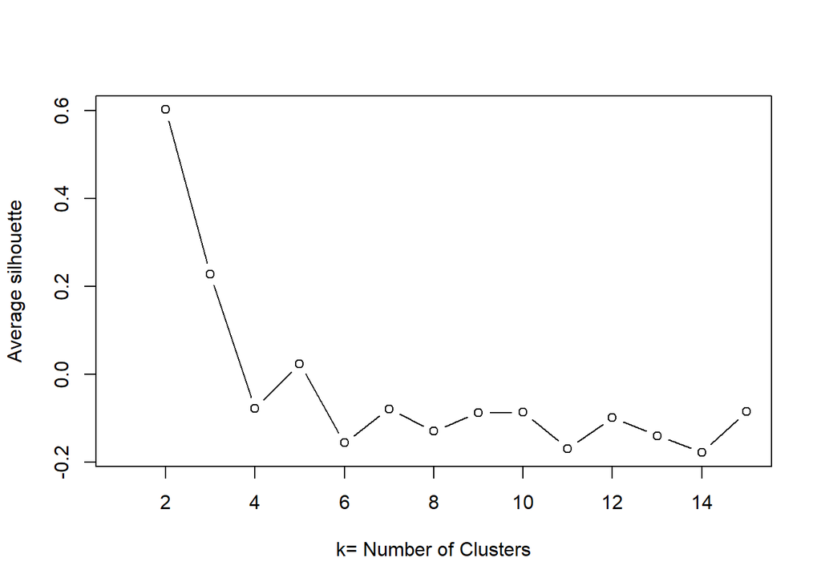

```r
set.seed(1)

sil <-NULL
for (i in 2:15)
{
  res <- pam(delta2,i)
  ss <- silhouette(res$cluster, dist(delta))
  sil[i] <- mean(ss[, 3])
}


plot(1:15, sil, type="b", xlab="k= Number of Clusters", ylab="Average silhouette")
```

Apply k-medoids with k=2

```r
set.seed(1)

kmedoids <- pam(delta2, 2)
```

Viewing results.

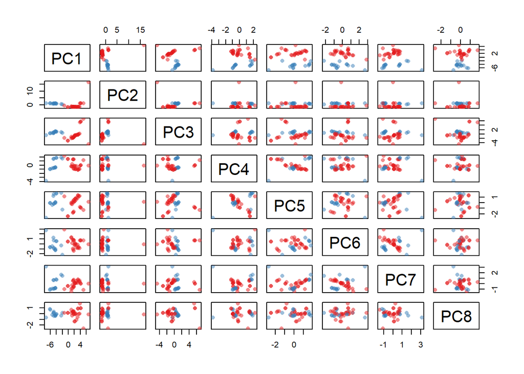

```r
#palette(alpha(brewer.pal(9,'Set1'), 0.5))
plot(delta2, col=kmedoids$clust, pch=16)
```

```r
sort(table(kmedoids$clust))
```

```
##
##  2  1
## 15 29
```

## Hierarchical clustering

### Using Euclidean distance

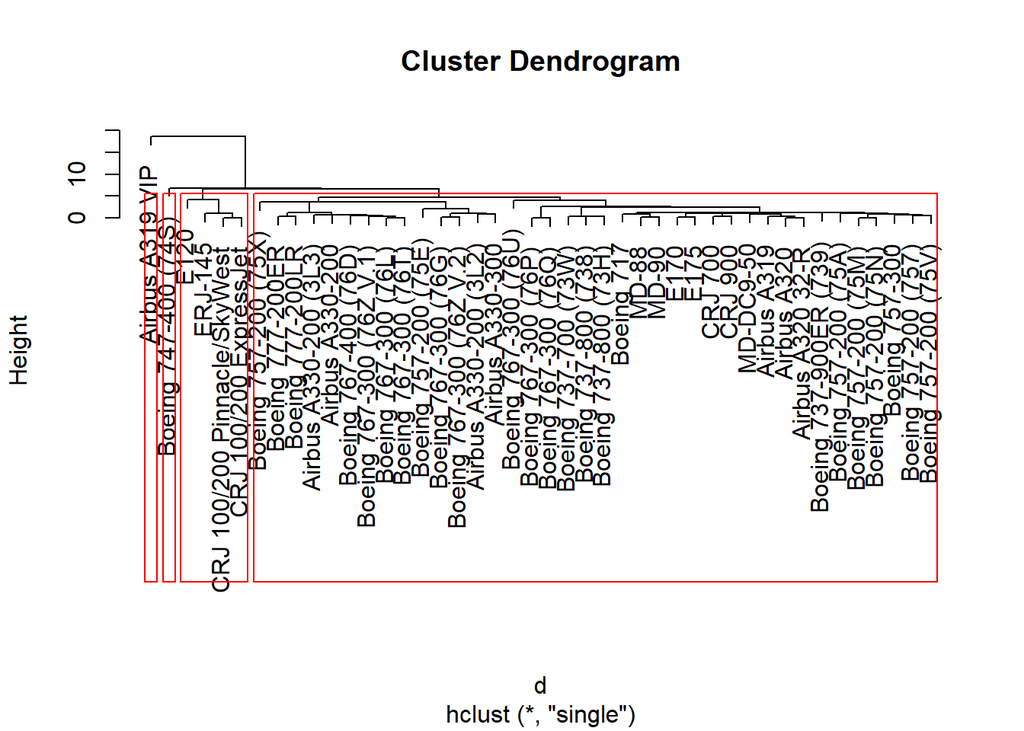

```r
d <- dist(delta2, method = "euclidean")
hc <- hclust(d, method="single")

# display dendogram
# plot.init()
plot(hc)

# cutting tree into 4 clusters
groups <- cutree(hc, k=4)

# drawing dendogram with red borders around the 4 clusters
rect.hclust(hc, k=4, border="red")
```

2 clusters contain just one instance. One cluster contains 4 instances and the fourth one contains the rest of the instances.

## Exercise 5 Using Manhattan distance

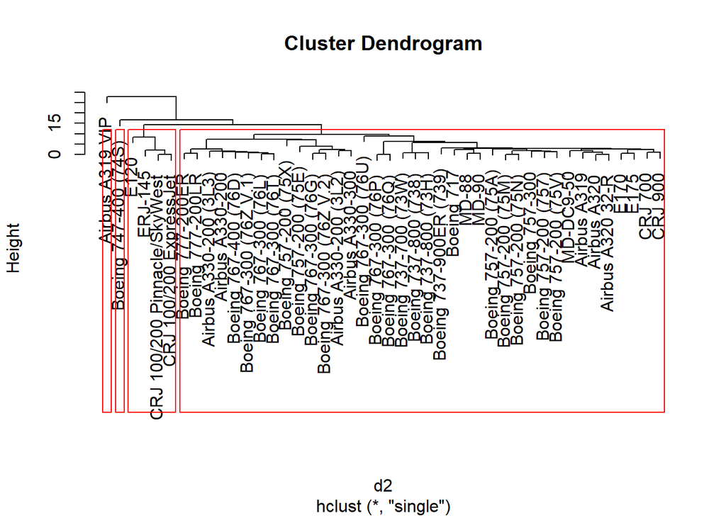

```r
d2 <- dist(delta2, method = "manhattan")
hc2 <- hclust(d2, method="single")

# display dendogram
#plot.init()
plot(hc2)

# cutting tree into 4 clusters
groups <- cutree(hc2, k=4)

# drawing dendogram with red borders around the 4 clusters
rect.hclust(hc2, k=4, border="red")
```

The clustering obtained is the same as with the Euclidean distance.

## Exercise 6

Using complete link.

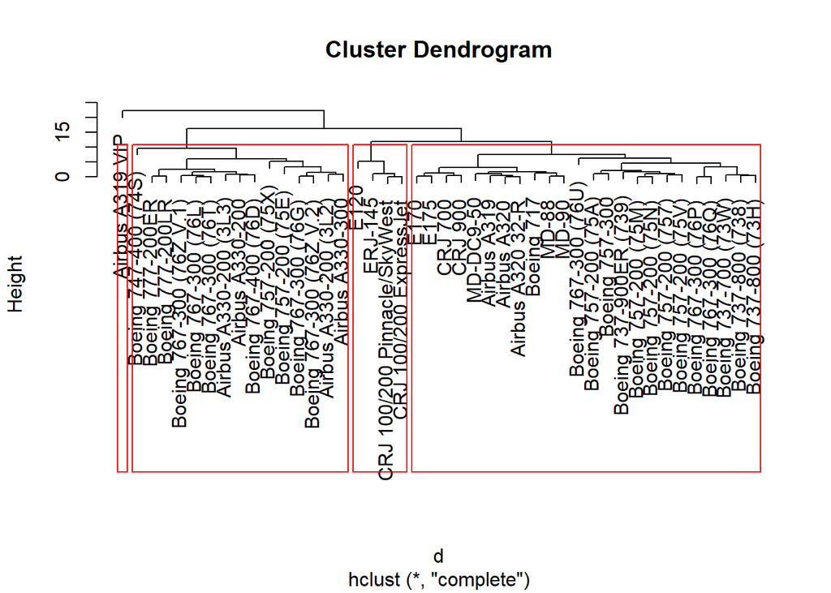

```r
d <- dist(delta2, method = "euclidean")
hc <- hclust(d, method="complete")

# display dendogram
# plot.init()
plot(hc)

# cutting tree into 4 clusters
groups <- cutree(hc, k=4)

# drawing dendogram with red borders around the 4 clusters
rect.hclust(hc, k=4, border="red")
```

The clustering has changed when compared to single link. Clusters 1 and 3 are the same as clusters obtained with single link but clusters 2 and 4 are very different. The clsutering looks the same as the one obtained using kmeans.

Using centroid.

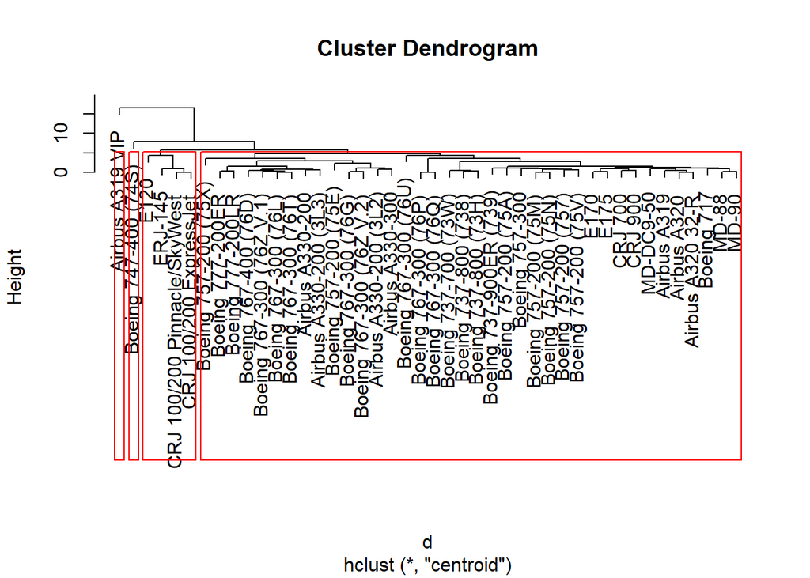

```r
d <- dist(delta2, method = "euclidean")
hc <- hclust(d, method="centroid")

# display dendogram
# plot.init()
plot(hc)

# cutting tree into 4 clusters
groups <- cutree(hc, k=4)

# drawing dendogram with red borders around the 4 clusters
rect.hclust(hc, k=4, border="red")
```

The clustering is the same as the one obtained using single link.

Using group average.

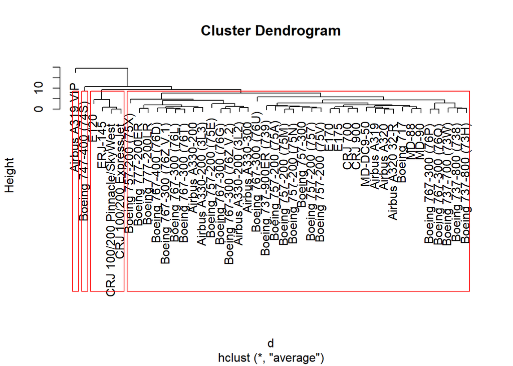

```r
d <- dist(delta2, method = "euclidean")
hc <- hclust(d, method="average")

# display dendogram
# plot.init()
plot(hc)

# cutting tree into 4 clusters
groups <- cutree(hc, k=4)

# drawing dendogram with red borders around the 4 clusters
rect.hclust(hc, k=4, border="red")
```

The clustering is the same as the one obtained using single link.

All schemas produce the same clustering except complete link,where the clustering is different. In most cases, 2 clusters contain just one instance. For complete link only one cluster contains one instance, a 2nd cluster contains 4 instances, a 3rd one contains 15 instances and the 4th one contains the rest of the instances.